# NHST vs estimation

Ian Hussey

The following contains simulations of single datasets. In each, 200 participants are simulated with a given true Cohen’s *d* value. Sequentially tested *p* values and estimations of Cohen’s *d* are then calculated for each dataset, in order to observe the change in *p* value size and confidence interval width and inclusion of zero across sequential tests.

In order to provide a proper estimate of the false discovery rate, a far larger number of studies would need to be simulated. This is done in a separate script - the goal here is to illustrate narrowing confidence intervals with increasing N rather than directly study the FDR.

# Simulated data where true effect is zero

Cohen’s d = 0.

## Simulation 1

### Sequentially tested *p* values

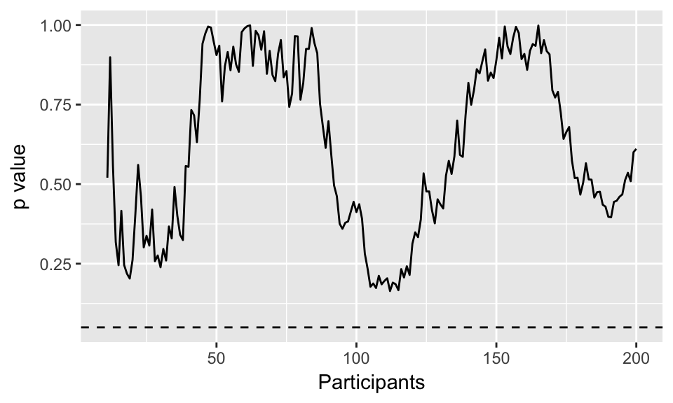

One or more false discoveries across all sequential tests: FALSE.

### Sequentially tested Cohen’s *d* estimates

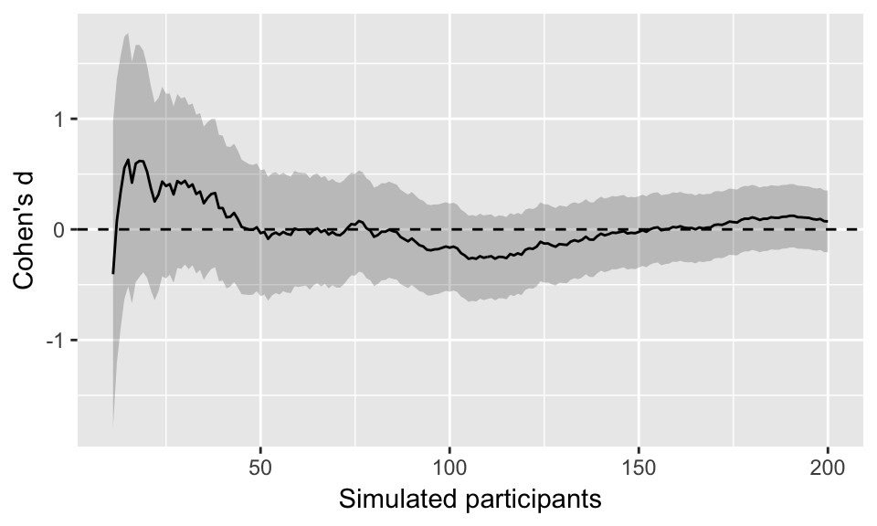

## Simulation 2

### Sequentially tested *p* values

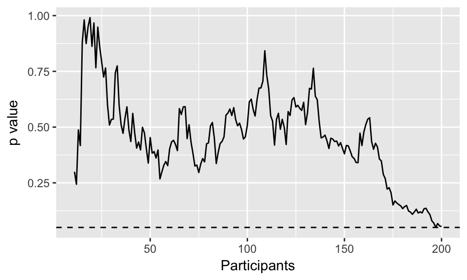

One or more false discoveries across all sequential tests: FALSE.

### Sequentially tested Cohen’s *d* estimates

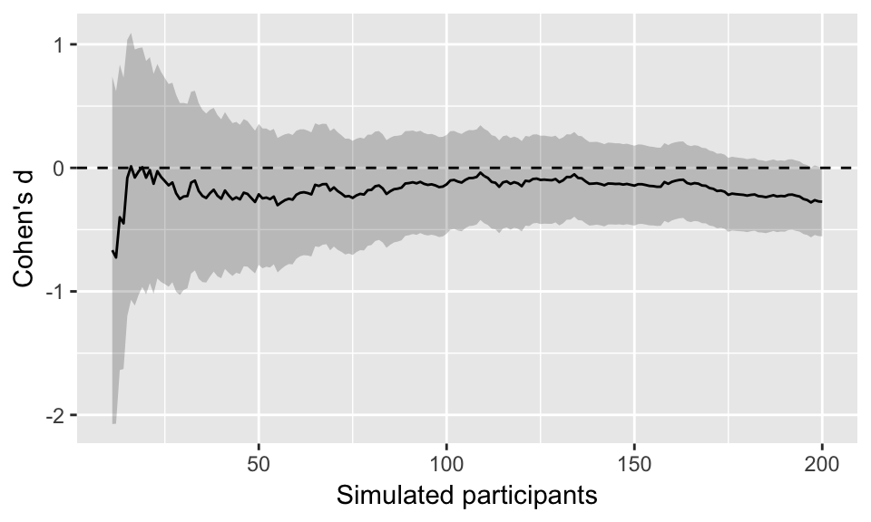

## Simulation 3

### Sequentially tested *p* values

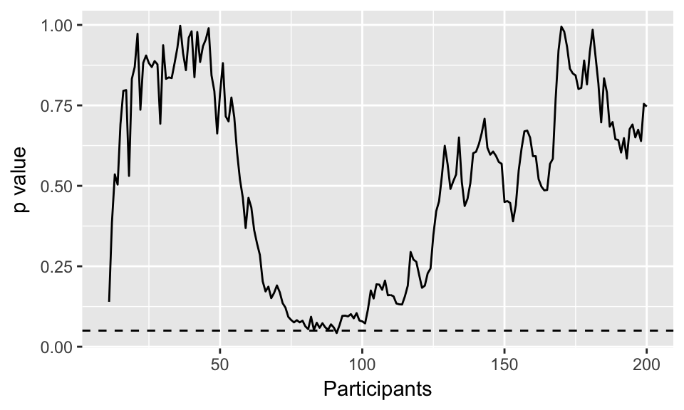

One or more false discoveries across all sequential tests: TRUE.

### Sequentially tested Cohen’s *d* estimates

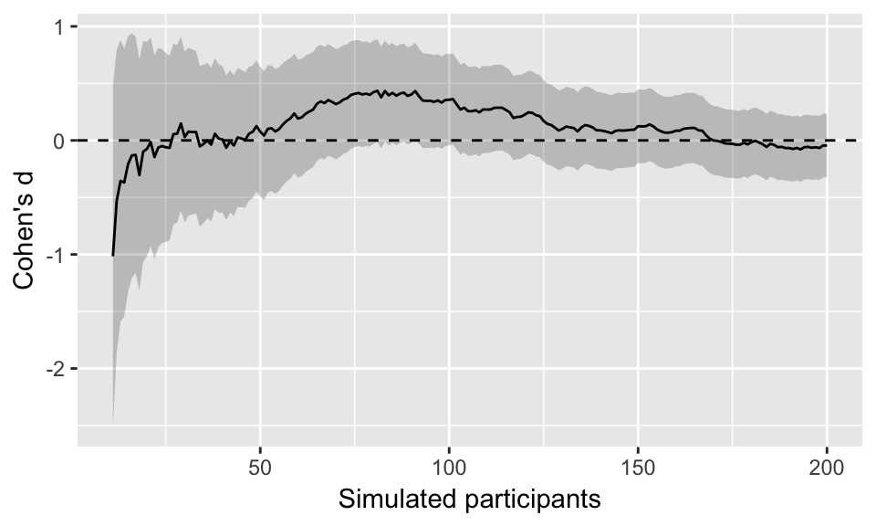

## Simulation 4

### Sequentially tested *p* values

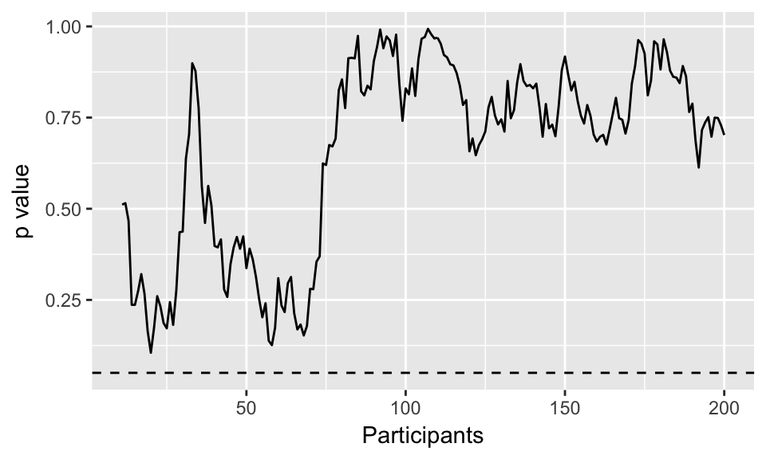

One or more false discoveries across all sequential tests: FALSE.

### Sequentially tested Cohen’s *d* estimates

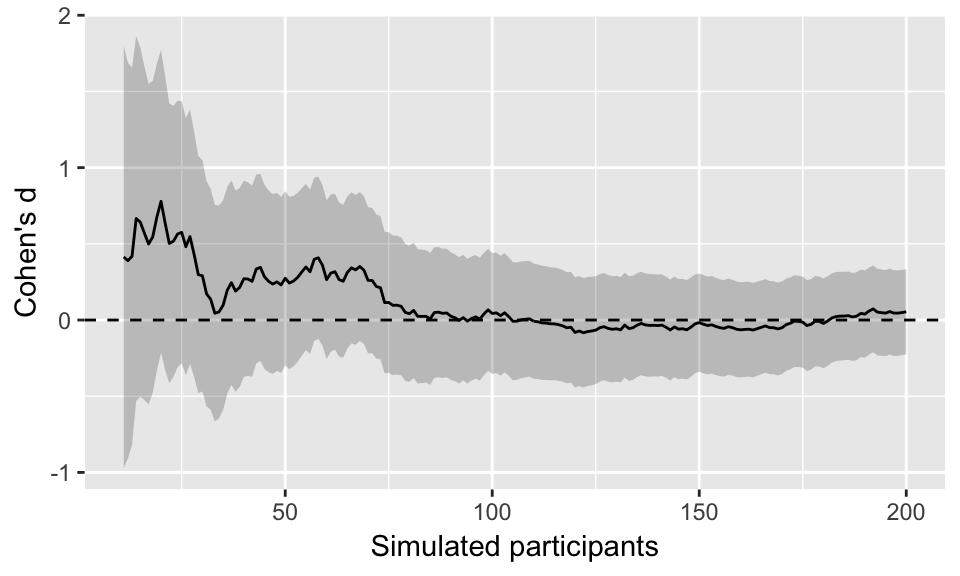

# Simulated data where true effect is of medium size

Cohen’s d = 0.5

## Simulation 1

### Sequentially tested *p* values

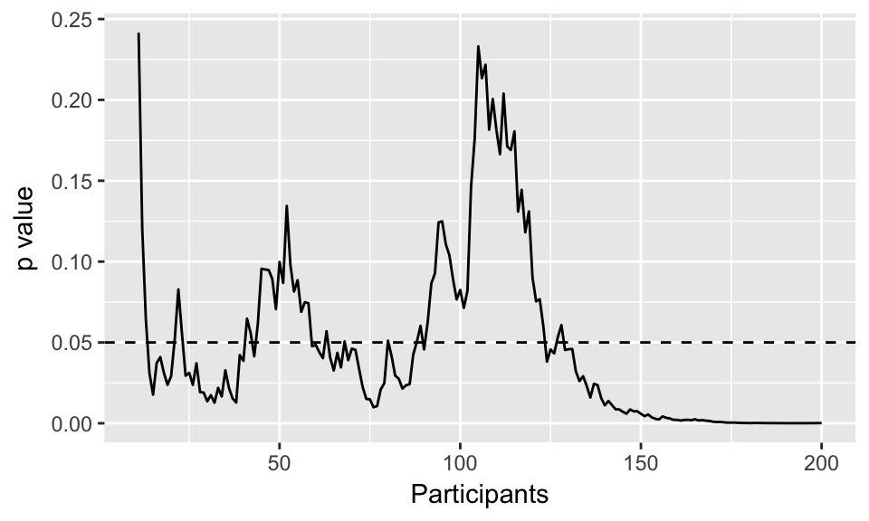

### Sequentially tested Cohen’s *d* estimates

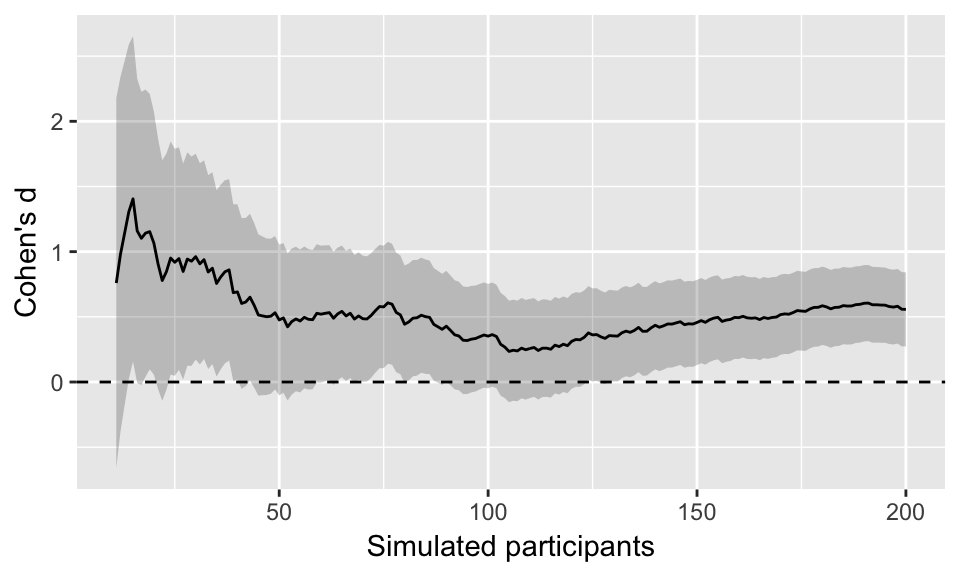

## Simulation 2

### Sequentially tested *p* values

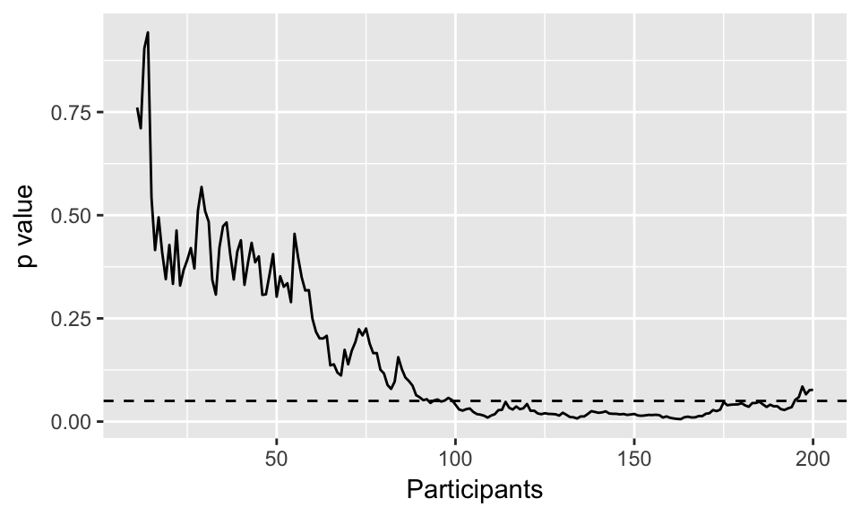

### Sequentially tested Cohen’s *d* estimates

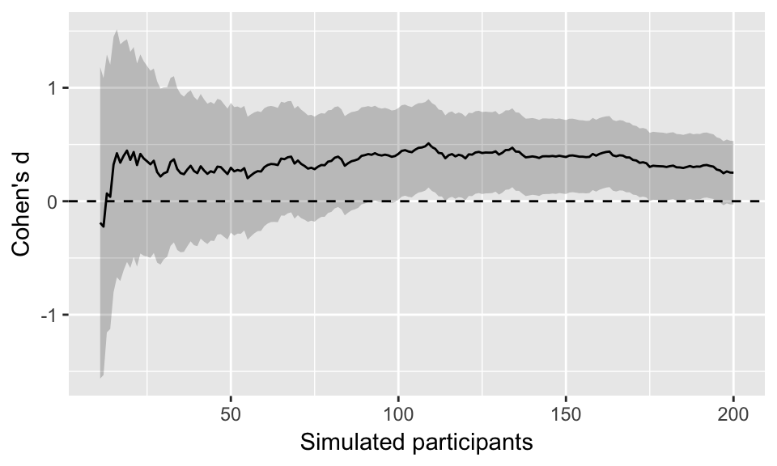

## Simulation 3

### Sequentially tested *p* values

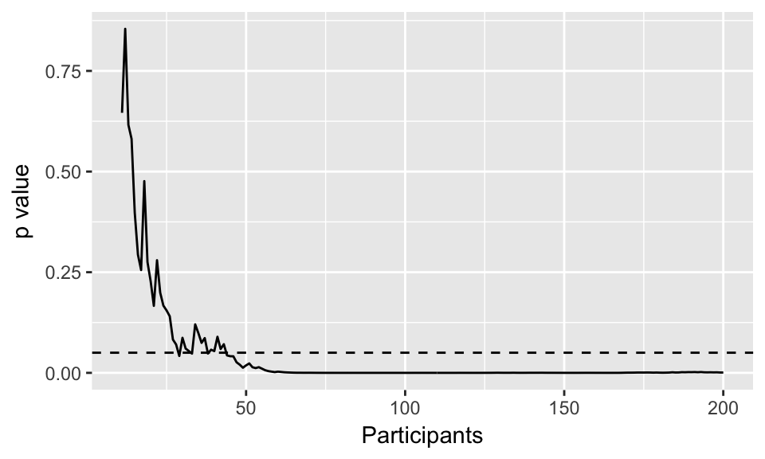

### Sequentially tested Cohen’s *d* estimates

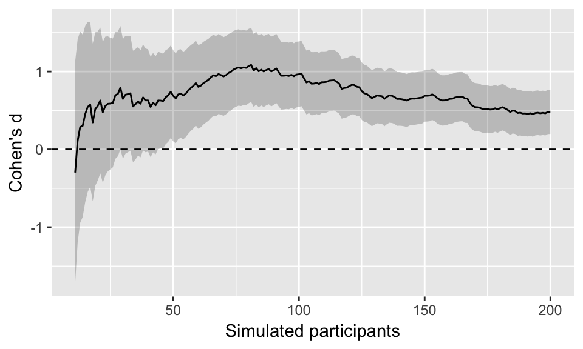

## Simulation 4

### Sequentially tested *p* values

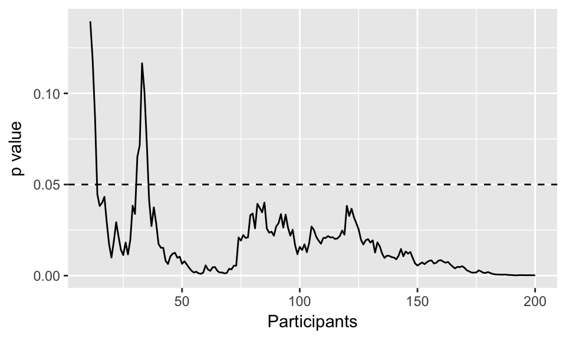

### Sequentially tested Cohen’s *d* estimates

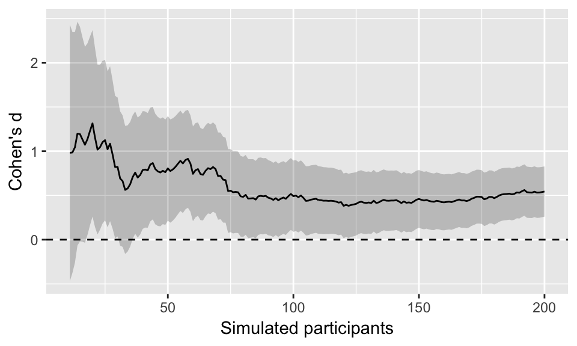

# Real data

Data taken from an actual experiment examining the influence of an evaluative learning task involving valenced stimuli and neutral and unknown Chinese characters. Between conditions, a source stimulus was varied to be either positively or negatively valenced. Outcome task was automatic evaluations of the Chinese characters on a Single-Category IAT.

### Sequentially tested *p* values

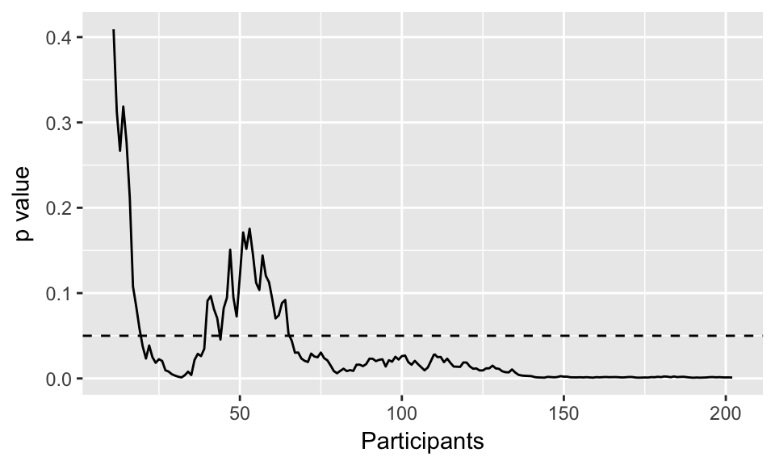

### Sequentially tested Cohen’s *d* estimates

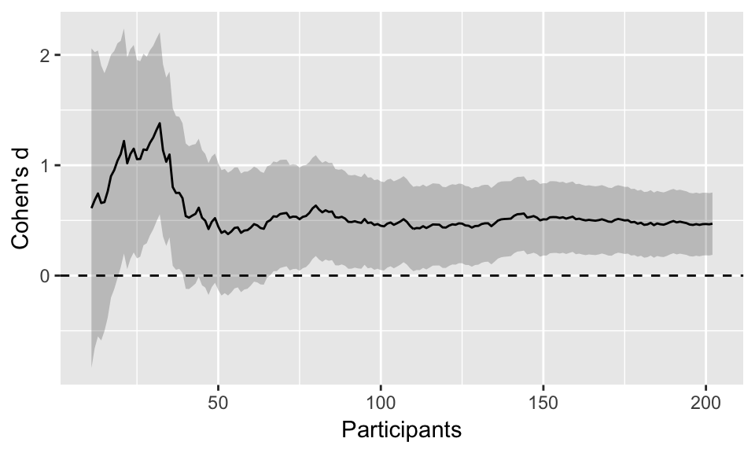